# Scaling for Malaria Metrics

February 16, 2024

Load the required packages:

```r
suppressMessages(library(exDE))
suppressMessages(require(deSolve))
suppressMessages(require(rootSolve))
suppressMessages(require(mobwork))
```

The function `xde_scaling()` defines the relationship between the EIR and the PR, and it outputs stable orbits for each value of aEIR in a mesh from $10^{-1}$ up to $10^{3}$ The code is in `mob_library/Work` Do we need two versions?

The cohort trace functions in `exDE` take the form of `F(a, bday=0, scale=1).`

```r
F_eir = function(a, bday=0, scale=1){scale*(1.01 + sin(2*pi*(a+bday)/365))}
```

```r
scl = integrate(F_eir, 0, 365)$value
```

```r
make_F_eir = function(F_eir, bday, scale){return(function(a, scl=1){scl*F_eir(a, bday, scale)})}
F_eir1 = make_F_eir(F_eir, 0, 1/scl)
```

```r
integrate(F_eir1, 0, 365, scl=2.3)$value
```

```
## [1] 2.3
```

```r
xde_setup_cohort(F_eir) -> sis
```

```r
xde_solve(sis) -> sis
```

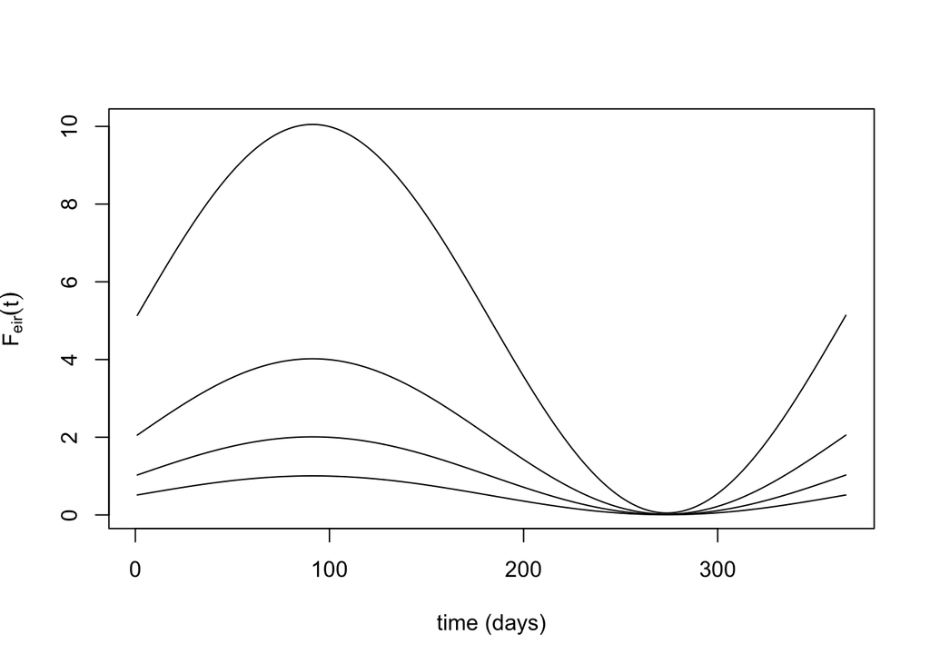

```r
tt = seq(0:365)
p1 = list()
p1$eirScale = 1
plot(tt, F_eir(tt, scale=5), type = "l", xlab = "time (days)", ylab = expression(F[eir](t)))
lines(tt, F_eir(tt, scale=2))
lines(tt, F_eir(tt))
lines(tt, F_eir(tt, scale = 1/2))
```

```r
xde_setup_cohort(F_eir) -> sis
```

```r
xde_scaling_eir(sis, 25) -> sis
```

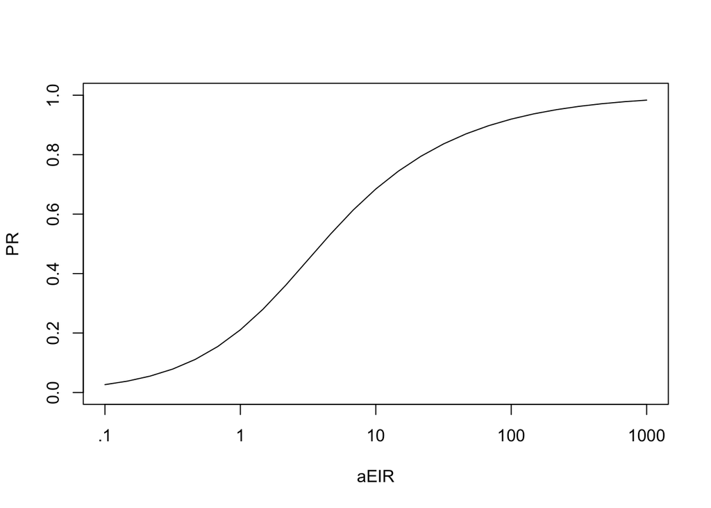

```r
plot_eirpr(sis)
```

```r
require(viridis)
clrs = turbo(25)
```

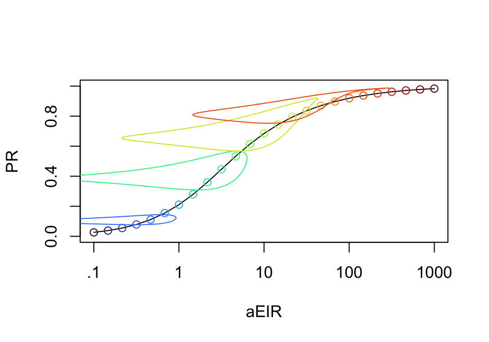

```r
plot_eirpr(sis)

with(sis$output$eirpr,{
  points(aeir, pr, col = clrs)
  lines(scaling[[5]]$aeir, scaling[[5]]$pr, col = clrs[5])
  lines(scaling[[10]]$aeir, scaling[[10]]$pr, col = clrs[10])
  lines(scaling[[15]]$aeir, scaling[[15]]$pr, col = clrs[15])
  lines(scaling[[20]]$aeir, scaling[[20]]$pr, col = clrs[20])
})
```

### `xde_pr2eir()`

Since `xde_scaling` defines the relationship between the EIR and the PR, we can now run `xde_pr2eir()` to get the predicted value of the eir, for any given value of the pr. The code is in `mob_library/Work`

```r
preir_i = xde_pr2eir(c(0.001, runif(25, 0, 1), 0.999), sis)
```

The function flags any values that are outside of the acceptable range. This may not seem important for the SIS model, but the range of other models can be bounded, so we don’t want to return nonsense values.

```r
preir_i$errors
```

```
##   pr1   pr2
## 0.001 0.999
```

We can plot the others:

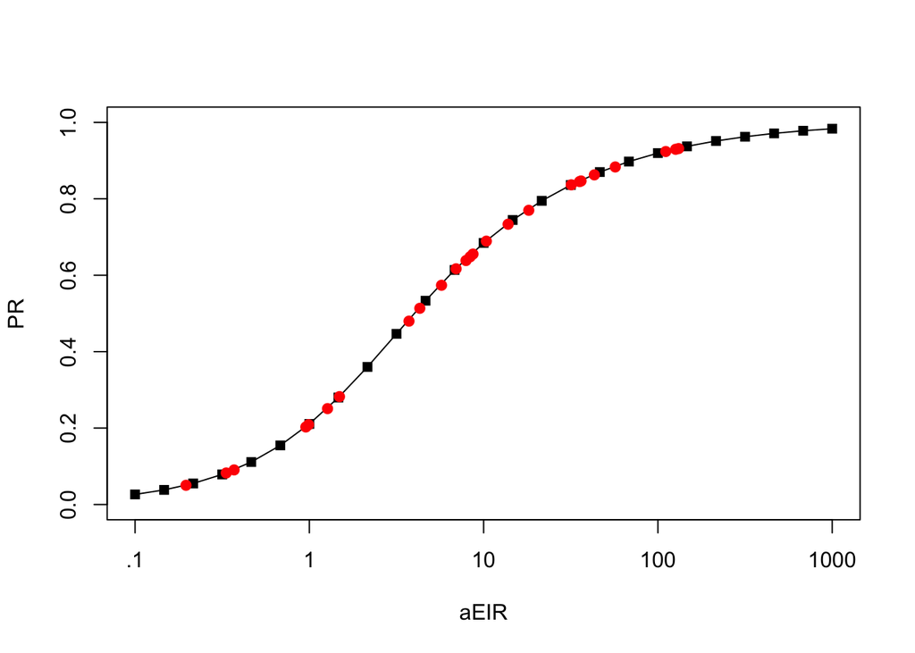

```r
plot_eirpr(sis)
with(sis$outputs$eirpr, points(aeir, pr, pch = 15))
with(preir_i, points(365*eir, pr, pch = 19, col = "red"))
```

### `split_stratum()`

```r
sis2 = split_stratum_by_biting(sis, 1, 1, .2, sqrt(10))
sis2 = split_stratum_by_biting(sis, 1, 1, .5, 1/sqrt(10))
sis2 <- xde_solve(sis2)
xde_scaling_eir(sis2, 25) -> sis2
```

```r
plot(sis$outputs$eirpr$aeir, sis$outputs$eirpr$pr, type = "l", log = "x", xaxt= "n", xlab = "aEIR", ylab = "PR")
axis(1, 10^(-1:3), c(0.1, 1, 10, 100, 1000))
lines(sis2$outputs$eirpr$aeir, sis2$outputs$eirpr$pr, col = "darkred")
```

[output not shown]

## Scaling

### $\oplus$

**To do**

- Codify the plotting protocols for $\cal X$
- Write SIP plotting protocols & `split_stratum`
- Get SIP up and running

### Seasonality

```r
F_eir0 = function(a, bday=0, scale=1){scale*(0*a+1)}
```

```r
sis0 = xde_setup_cohort(F_eir0)
xde_scaling_eir(sis0, 25) -> sis0
```

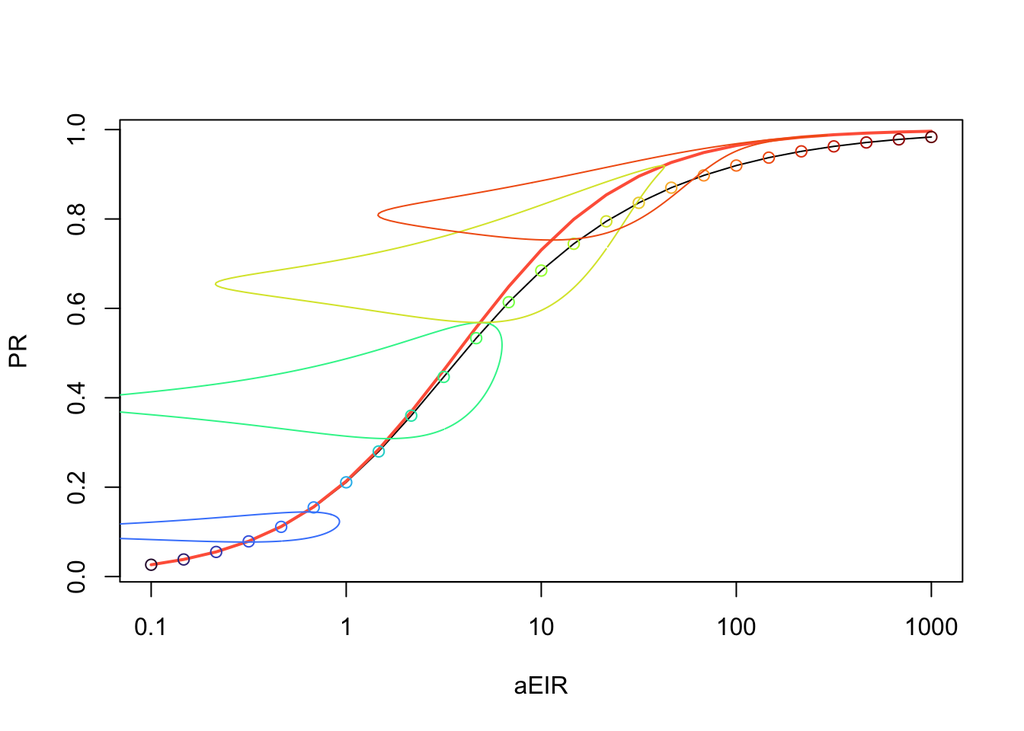

```r
clrs = turbo(25)
with(sis$outputs$eirpr, plot(aeir, pr, type = "l", log = "x", xaxt= "n", xlab = "aEIR", ylab = "PR"))
axis(1, 10^(-1:3), c(0.1, 1, 10, 100, 1000))
lines(sis0$outputs$eirpr$aeir, sis0$outputs$eirpr$pr, col = "tomato", lwd=2)

with(sis$outputs$eirpr, points(aeir, pr, col = clrs))
with(sis$outputs$eirpr, lines(scaling[[5]]$aeir, scaling[[5]]$pr, col = clrs[5]))
with(sis$outputs$eirpr, lines(scaling[[10]]$aeir, scaling[[10]]$pr, col = clrs[10]))
with(sis$outputs$eirpr, lines(scaling[[15]]$aeir, scaling[[15]]$pr, col = clrs[15]))
with(sis$outputs$eirpr, lines(scaling[[20]]$aeir, scaling[[20]]$pr, col = clrs[20]))
```

### Drug taking

```r
sip = xde_setup_cohort(F_eir0, Xname = "SIP")
sip$Xpar[[1]]$eta = 1/40
xde_scaling_eir(sip, 25) -> sip
sip1 = setup_exposure_nb(sip, 1/50)
xde_scaling_eir(sip1, 25) -> sip1
```

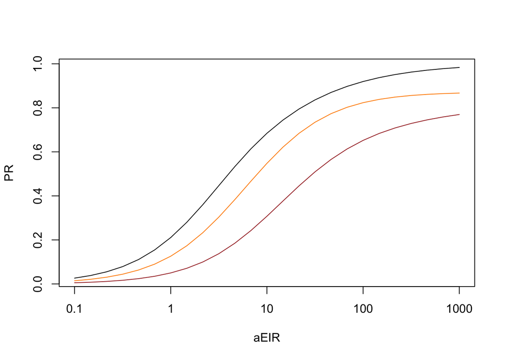

```r
with(sis$outputs$eirpr, plot(aeir, pr, type = "l", log = "x", xaxt= "n", xlab = "aEIR", ylab = "PR"))
axis(1, 10^(-1:3), c(0.1, 1, 10, 100, 1000))
with(sip$outputs$eirpr, lines(aeir, pr, col = "darkorange"))
with(sip1$outputs$eirpr, lines(aeir, pr, col = "brown"))
```

### Heterogeneity

```r
#sis3 <- setup_exposure_nb(sis2, 1/50)
sis4 <- setup_exposure_nb(sis, 1/50)
#xde_scaling_eir(sis3, 25) -> sis3
xde_scaling_eir(sis4, 25) -> sis4
```

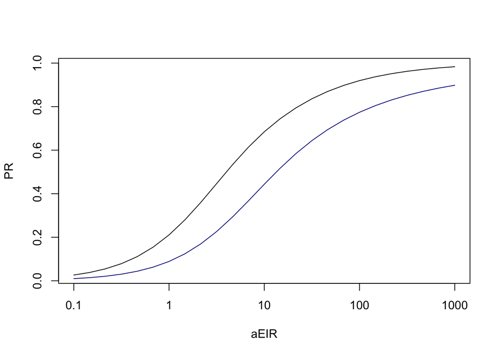

```r
with(sis$outputs$eirpr, plot(aeir, pr, type = "l", log = "x", xaxt= "n", xlab = "aEIR", ylab = "PR"))
axis(1, 10^(-1:3), c(0.1, 1, 10, 100, 1000))
#with(sis2$outputs$eir, lines(aeir, pr, col = "blue"))
#with(sis3$outputs$eir, lines(aeir, pr, col = "purple"))
with(sis4$outputs$eir, lines(aeir, pr, col = "darkblue"))
```

### travel

```r
sis5 <- setup_travel_foi(sis, delta_scale = 1/5/365)
xde_scaling_eir(sis5, 25) -> sis5
```

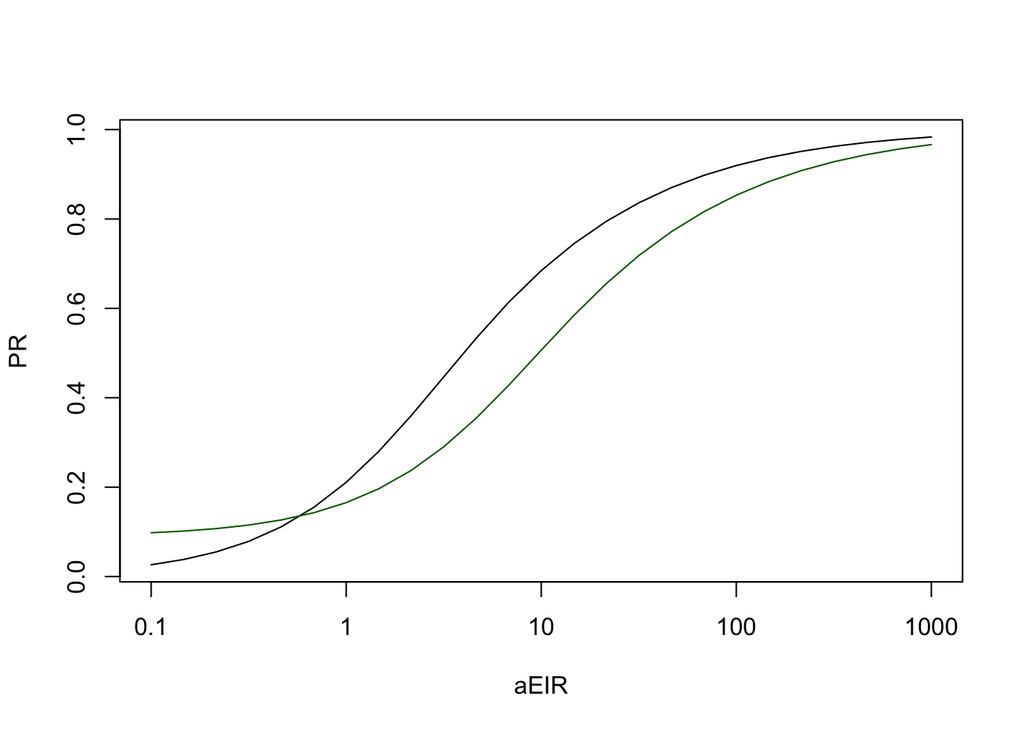

```r
with(sis$outputs$eirpr, plot(aeir, pr, type = "l", log = "x", xaxt= "n", xlab = "aEIR", ylab = "PR"))
axis(1, 10^(-1:3), c(0.1, 1, 10, 100, 1000))
with(sis5$outputs$eir, lines(aeir, pr, col = "darkgreen"))
```

### cohorts

**To do**

Fix `eir2pr` so it works.

source_mob_library()

eir2pr_steady(rm) -> ep

## $\boxplus$

### What is a model?

[Model scoping](https://www.ibm.com/docs/en/dmeu/2.0?topic=tasks-scoping-data-models)

> Scoping is the act of identifying a subset of elements within a larger set. When you scope a data model, you create a diagram to hold all the elements that are part of your scope. The diagram represents a view of your scope. Attributes that are part of the scope are highlighted with a color. Attributes that are not part of the scope are set as non-persistent.

[Model Features]

range / skill / adequacy

### `parse_deout`

- the function `parse_deout` should compute and store all of these quantities
  - the true PR
    - by season
    - by age from `age_membership`
    - by sex from `sex_membership`
    - *by location* - requires `patch_membership`
    - *by trait* - requires `trait_membership`
  - the observed PR
    - with generic simple detection
    - *by light microscopy* (if defined)
    - *by RDT* (if defined)
    - *by PCR* (if defined)
  - the EIR

### other exDE

- Finalize the changes to accommodate **Exogenous Forcing**
- I/O
- copy `solving.R` to `steady.R` and copy the `xde_solve` family of functions to `xde_steady`